# ezDAFi

Pedro Milanez Almeida

1/13/2020

### Executive Summary

The objective of this report is to present ezDAFi, an easy-to-use FlowJo plugin for DAFi. DAFi stands for **D**irected **A**utomated **F**iltering and **I**dentification of cell populations in polychromatic flow cytometry data (see [original publication](https://doi.org/10.1002/cyto.a.23371)). The plugin automatically imports single-cell data and FlowJo-derived gating strategies into R, builds single cell representations either with self-organizing maps (SOM) or k-means, and updates single cell identities according to the location of their nearest cluster centroid within the gating tree. The plugin can be used to refine gated populations on the fly in FlowJo, allowing for the visual check and re-use of DAFi gated cells in downstream analysis, such as building stats, plots and more gates.

### Motivation

With the advent of high dimensional single cell interrogation technologies, bidimensional manual gating became obsolete. This led to a quick rise in the number of automatic clustering algorithms for biological and immunological research but several problems are associated with automated gating strategies, such as:

- Combining automated data analysis with human knowledge about gene/protein expression levels in specific cell types that perform a certain function of interest.
- Validate the results of automatic clustering.
- Dealing with batch effects. If manual gating is used, one can subjectively (or semi-automatically) shift a gate, but if clustering is used, one often finds new “populations”.

DAFi tries to solve some of these problems. The basic idea behind DAFi is to gate the centroids of clustering results with the manual gating strategy and update single cell identity according to within which gate the nearest neighboring centroid is located, if any.

The algorithm works like this:

- Cluster single cells using a high number of clusters;
- Gate the cluster centroids using manual gates;
- Merge clusters if their centroids are inside a given gate;
- Cells whose nearest neighbors is one of merged clusters belong to one merged population.

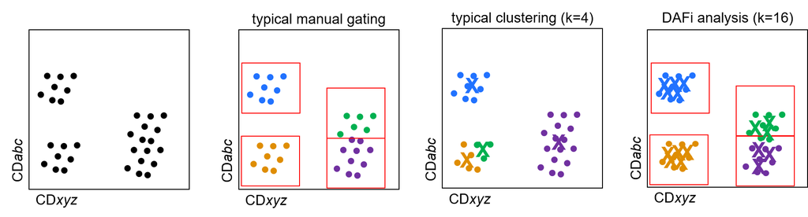

**Fig1**: How DAFi aims at bridging manual gating and automated clustering techniques.

### Reported advantages of DAFi

Several advantages of DAFi have been reported (see [original publication](https://doi.org/10.1002/cyto.a.23371)):

- Better separation of poorly-resolved populations
- Abrupt cut in manual gating vs “natural” shape of data distribution in DAFi
- Higher interpretability of automated clustering
- When used recursively, higher chances of finding smaller populations than in automated clustering
- Effective use of human knowledge in guiding automated algorithms

### ezDAFi in action: DAFi from inside Flowjo

Our new implementation of DAFi relies on R and several R packages, in particular flowWorkspace, to bring DAFi to FlowJo in the form of an easy-to-use plugin.

While building the gating tree, the user can select a parent population, call the plugin and refine any child population using DAFi. The DAFi-refined gates are automatically imported back to FlowJo for futher downstream analysis, including plotting, stats and further gating.

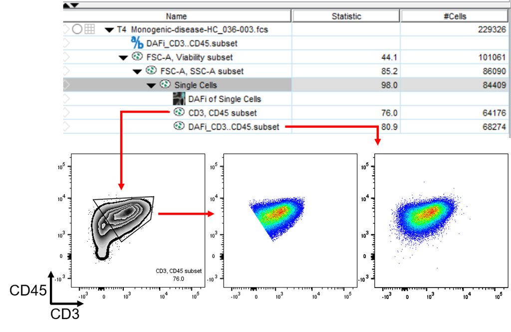

**Fig2**: Selecting “Single Cells” and running the plugin will refine either all gates down the hierarchy from “Single Cells” or only the immediate children, depending on user input. In this case, we only show one example of one immediate child gate, the “CD3, CD45 subset”. Please note how the DAFi-refined population shows a much more natural distribution of the parameters after gating.

Importantly, if the user decides to build the whole gating tree first and to apply DAFi to an upstream gate, the plugin can be used to refine all children and children of children of a seleted population. This feature allows for DAFi to be used recursively throughout several levels of the gating tree without additional human interaction. This way, all sub-populations downstream of the selected gate will be refined by DAFi.

## Conclusion

Our new plugin brings the power of DAFi to FlowJo, the most widely used single cell flow cytometry data analysis platform. This new implementation allows for the use of DAFi on the fly, giving the user the flexibility to re-use DAFi-refined populations with any of FlowJo’s downstream analysis capabilities.

## Notes and Source

#### Processing time

- Depends on the number of centroids to be used
- First run can take a few minutes to install required R packages
- Since data are saved to hard disk, it may run slow on some older systems

#### Known Bugs

- DAFi-ing children of DAFi gates does not work. The plugin creates derived parameters (zeros and ones), which are used to DAFi-gate cells in FlowJo. FlowJo-derived parameters are not imported into flowWorkspace in R, such that DAFi gates are not recognized in R for DAFi analysis of children of DAFi gates. TODO: make derived parameters exportable/readable in R.
- Every DAFi-gate generates one derived parameter, overpopulating the view. TODO: Import derived parameters from R into FlowJo as one parameter for each DAFi run.
- R error messages are not visible to the user. TODO: Make R error messages visible to the user

#### Github Page:

github.com/PedroMilanezAlmeida/DAFi

#### Google Drive:

https://drive.google.com/drive/folders/1fdTVdbz8S_v58oPX8jpYDudL4wRAge2a